# Final Projec: Creating a Logistic Regression Package

Gropu 7:Favour Onyido, Manisha Parajuli, Festus Attah

2022-12-03

```r
library(irg)
library(logregG7)
```

In this file, we are describing the package logregG7. We created the package using a sample dataset from canvas. The package can be downloaded from the github repo link using [logreG7](https://github.com/AU-R-Data-Science/Finalproject_G7) and the link in parenthesis: (devtools::install_githubAU-R-Data-Science/Finalproject_G7) in your console.

NB:Be sure to have “devtools” already installed in R.

## Data Pre-Processing

In this section we will use the covid.csv data from canvas to test our package. We first read the csv file into our environment and omit all rows with `NA` value. We then select two columns we would use as our dependent and independent variable, y and x respectively.

```r
df <-  na.omit(read.csv("covid.csv", header=TRUE))

y <- as.numeric(factor(df$Symptoms, labels = c(0, 1)))
x <- matrix(as.numeric(as.factor(df$Hospitalization.type)))
```

Once our data has been pre-processed and read into our environment, we can begin using the functions from our package.

First we can optimize our cost function and train it using the `optim_log()` function from our package. It returns an intercept and coefficient.

```r
Optim_log(x,y)
```

```
##                  [,1]
## intercept 35.75843502
##            0.08791177
```

## Boostrapping Procedure

By default, it uses $20$ and $0.05$ as the default number of bootstrap replications and alpha value respectively. The parameter can be adjusted to the user specification by changing the `b` and `alpha` values.

Thus user has total control over the parameter and number of bootstrap replications.

```r
bootstrap_confi(x,y)
```

```
##       beta_mean lower_bound upper_bound
## [1,] 34.6402737    19.91544   49.365106
## [2,]  0.1399943    -5.40463    5.684618
```

```r
bootstrap_confi(x,y, b=50, alpha = 0.10)
```

```
##      beta_mean lower_bound upper_bound
## [1,] 28.660350    5.379455    51.94124
## [2,]  2.326046   -5.862274    10.51437
```

```r
#Notice how the computed values changes
```

## Plotting the predicted probabilities vrs the true data points

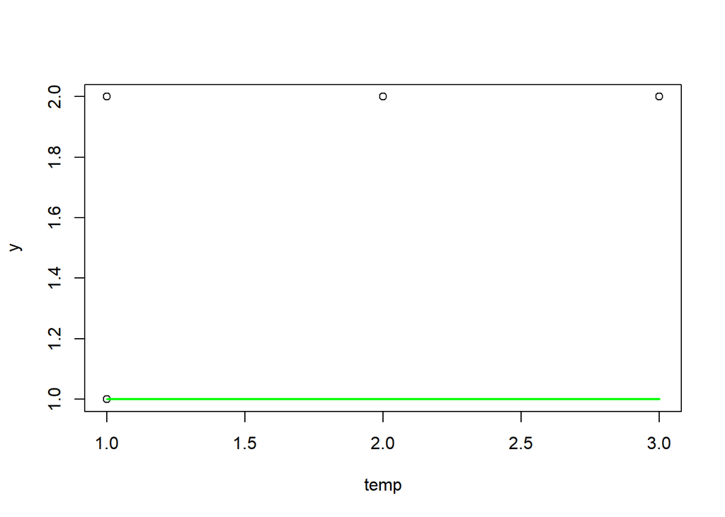

```r
plot_predict(x,y)
```

## Confusion Matrix

We also have the ability to generate a confusion matrix of the predicted values against the actual values using the conf_mat() function. The fuction uses 0.5 as the cutoff value, however you can provide yours by including “cuttoff={value}” as a parameter. This function returns a table which can use used in the next function.

```r
conf_mat(x,y)
```

```
##           Reference
## Prediction Negative Positive
##   Negative        3      812
##   Positive        0        0
```

Several calculations can be made from the generated confusion matrix using the `cal_confusion_matrix()` function. It accepts two values, the actual confusion matrix table (the item returned by the conf_mat() table above) and a 3- letter character indicating what calculation you’d like to make (by default, it calculates the accuracy)).

- “pre” for Prevalence
- “acc” for Accuracy
- “sen” for Sensitivity
- “spe” for Specificity
- “fdr” for False Discovery Rate
- “dor” for Diagnostic Odds Ratio

```r
cal_confusion_matrix(conf_mat(x,y))
```

```
## [1] "Accuracy is 0.00368098159509202"
```

Finally, `cal2()` function allows you to compute a calculation of your choice just like in cal_confusion_matrix() but this time it gives you the value of the calculation for a range of cuttoffs between $0.1 - 0.9$. It also then plots this values. `cal2()` does not use a default value so you would have to let it know what calculation you would like to make.

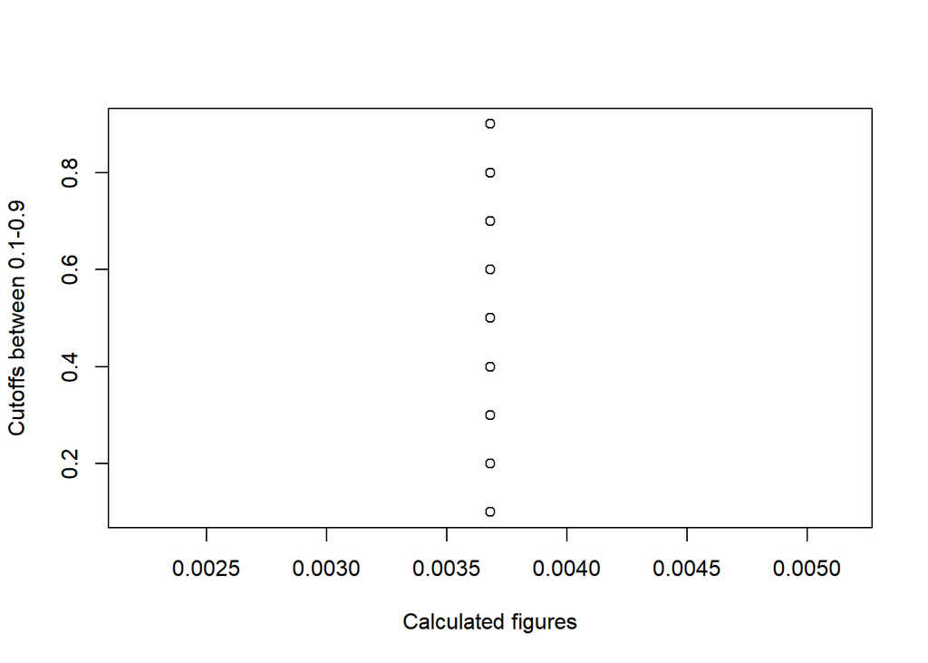

```r
cal2(x,y,"acc")
```

*A more robust example is provided in the test.R file on the github repo using a better dataset example.*